# Sentiment Index 5-14-2020

# Correlation of EF and BF Sent by Year

### A Pearson’s correlation test also shows the weakness in comparing the two sentiments.

### This test shows p-value = 0.04128, which suggests a somewhat significant relationship between average negative sentiment in the Broad Filter and Economic Filterc news articles

```r
cor.test(BF_EFsent$EF_yravg, BF_EFsent$BF_yravg, method = "pearson")
```

```
##
##  Pearson's product-moment correlation
##
## data:  BF_EFsent$EF_yravg and BF_EFsent$BF_yravg
## t = 2.1979, df = 18, p-value = 0.04128
## alternative hypothesis: true correlation is not equal to 0
## 95 percent confidence interval:
##  0.0219308 0.7498693
## sample estimates:
##       cor
## 0.4599875
```

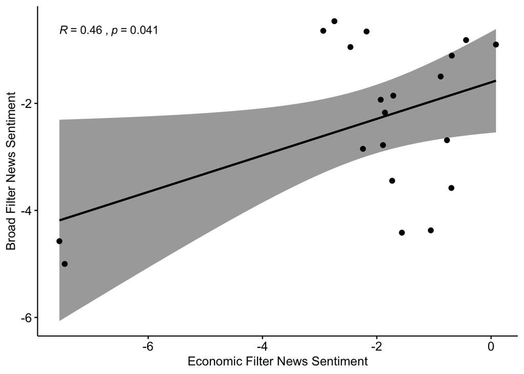

```r
ggscatter(BF_EFsent, x = "EF_yravg", y = "BF_yravg",
          add = "reg.line", conf.int = TRUE,
          cor.coef = TRUE, cor.method = "pearson",
          xlab = "Economic Filter News Sentiment", ylab = "Broad Filter News Sentiment")
```

```r
  glimpse(BF_EFsent)
```

```
## Observations: 20
## Variables: 3
## $ year     <int> 2000, 2001, 2002, 2003, 2004, 2005, 2006, 2007, 2008, 2…
## $ EF_yravg <dbl> 0.0852459, -0.6944444, -0.6875000, -1.7114094, -2.74172…
## $ BF_yravg <dbl> -0.9000000, -3.5803213, -1.1073446, -1.8553719, -0.4640…
```

# Combined single sentiment score called index

```r
#Adding the Bing sentiment scores
BF_EFsent <- BF_EFsent %>%
  mutate(index = (EF_yravg + BF_yravg))
head(BF_EFsent)
```

```
##   year   EF_yravg  BF_yravg      index
## 1 2000  0.0852459 -0.900000 -0.8147541
## 2 2001 -0.6944444 -3.580321 -4.2747657
## 3 2002 -0.6875000 -1.107345 -1.7948446
## 4 2003 -1.7114094 -1.855372 -3.5667813
## 5 2004 -2.7417219 -0.464000 -3.2057219
## 6 2005 -1.9310345 -1.931507 -3.8625413
```

```r
#write.csv(BF_EFsent, "./Sentiment Analysis/news_sentiment_index.csv")
```

The average sentiment is -4.469829

```r
mean(BF_EFsent$index)
```

```
## [1] -4.469829
```

### A chart of China News Sentiment by Year. This is the sum of the Economic and General News Sentiment

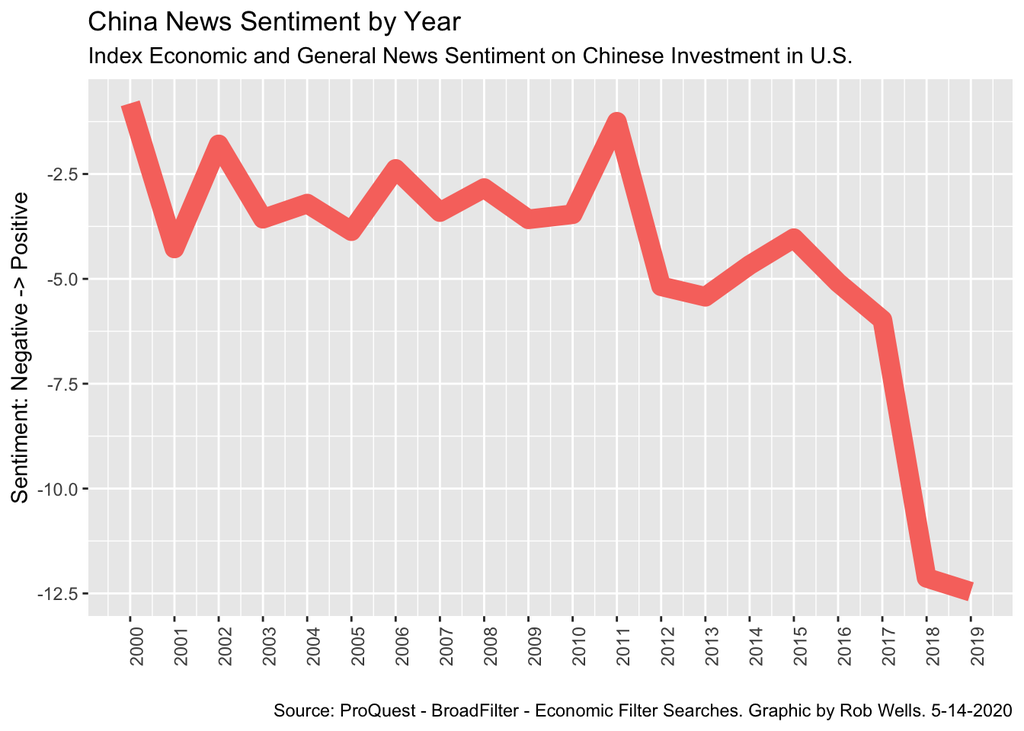

```r
BF_EFsent %>%
ggplot(aes(x= year, y= index, color = "red", size = 3)) +
#ggplot(aes(x= year, y= index, color = index > -4.469829, size = 3)) +
  geom_line() +
  scale_x_continuous(breaks=c(2000:2019)) +
  theme(legend.position = "none") +
   theme(axis.text.x = element_text(angle = 90, hjust = 1)) +
   labs(title = "China News Sentiment by Year",
       subtitle = "Index Economic and General News Sentiment on Chinese Investment in U.S.",
       caption = "Source: ProQuest - BroadFilter - Economic Filter Searches. Graphic by Rob Wells. 5-14-2020",
       x=" ",
       y="Sentiment: Negative -> Positive")
```

```r
ggsave("./Sentiment Analysis/sentiment_index3.png",device = "png",width=10,height=8, dpi=800)
```

### The calculation below is the average of the Economic and General News scores into a new index. This average helps smooth out the variations in the data.

```r
#Averaging the Bing sentiment scores
z <- BF_EFsent %>%
  mutate(index = (EF_yravg + BF_yravg)/2)
head(z)
```

```
##   year   EF_yravg  BF_yravg      index
## 1 2000  0.0852459 -0.900000 -0.4073770
## 2 2001 -0.6944444 -3.580321 -2.1373829
## 3 2002 -0.6875000 -1.107345 -0.8974223
## 4 2003 -1.7114094 -1.855372 -1.7833906
## 5 2004 -2.7417219 -0.464000 -1.6028609
## 6 2005 -1.9310345 -1.931507 -1.9312707
```

```r
#write.csv(BF_EFsent, "./Sentiment Analysis/news_sentiment_index.csv")
```

The average sentiment is -2.234914

```r
mean(z$index)
```

```
## [1] -2.234914
```

### This chart of the average sentiment index shows the same pattern but on a scale without as much dramatic variation.

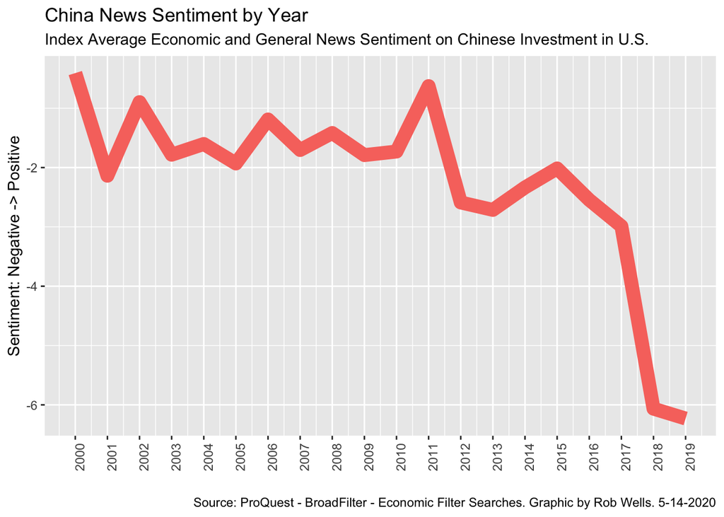

```r
z %>%
ggplot(aes(x= year, y= index, color = "red", size = 3)) +
#ggplot(aes(x= year, y= index, color = index > -2.234914, size = 3)) +
  geom_line() +
  scale_x_continuous(breaks=c(2000:2019)) +
  theme(legend.position = "none") +
   theme(axis.text.x = element_text(angle = 90, hjust = 1)) +
   labs(title = "China News Sentiment by Year",
       subtitle = "Index Average Economic and General News Sentiment on Chinese Investment in U.S.",
       caption = "Source: ProQuest - BroadFilter - Economic Filter Searches. Graphic by Rob Wells. 5-14-2020",
       x=" ",
       y="Sentiment: Negative -> Positive")
```

```r
ggsave("./Sentiment Analysis/sentiment_index3.png",device = "png",width=10,height=8, dpi=800)
```

# Custom Sentiment Score

### Join and compare custom sentiment scores for Economic and Broad Filter

### The Custom Sentiment Score is based on a custom dictionary of 177 terms specifically focused on trade discourse whose sentiment were scored by the authors

### Here is the Economic News scored by the Custom Sentiment Score

```r
#import EF custom sentiment score from Sentiment Broad Filter 5-14-2020
EFcust <- rio::import("./Sentiment Analysis/custom_by_year_EF.csv")
colnames(EFcust)[3] <- c("EF_custom_total")
head(EFcust)
```

```
##   V1 year EF_custom_total
## 1  1 2000        5.915493
## 2  2 2001        1.370370
## 3  3 2002       -1.555556
## 4  4 2003       -3.610169
## 5  5 2004       -5.148148
## 6  6 2005       -1.139241
```

### Here is the General News scored by the Custom Sentiment Score

```r
BFcust <- rio::import("./Sentiment Analysis/custom_by_year_BF.csv")
colnames(BFcust)[3] <- c("BF_custom_total")
head(BFcust)
```

```
##   V1 year BF_custom_total
## 1  1 2000       -3.719298
## 2  2 2001      -16.829787
## 3  3 2002       -6.843137
## 4  4 2003      -11.028169
## 5  5 2004       -5.347826
## 6  6 2005       -6.366337
```

### General and Economic news scores joined by year

```r
BF_EFcust <- EFcust %>%
  inner_join(BFcust, by = "year")
```

### Custom Scores for Economic and General Table Cleaned

```r
BF_EFcust  <- BF_EFcust  %>%
  select(year, EF_custom_total, BF_custom_total)
head(BF_EFcust)
```

```
##   year EF_custom_total BF_custom_total
## 1 2000        5.915493       -3.719298
## 2 2001        1.370370      -16.829787
## 3 2002       -1.555556       -6.843137
## 4 2003       -3.610169      -11.028169
## 5 2004       -5.148148       -5.347826
## 6 2005       -1.139241       -6.366337
```

### A new index is created with the average of the general and economic custom scores

```r
BF_EFcust <- BF_EFcust %>%
  mutate(index = (EF_custom_total + BF_custom_total)/2)
head(BF_EFcust)
```

```
##   year EF_custom_total BF_custom_total     index
## 1 2000        5.915493       -3.719298  1.098097
## 2 2001        1.370370      -16.829787 -7.729708
## 3 2002       -1.555556       -6.843137 -4.199346
## 4 2003       -3.610169      -11.028169 -7.319169
## 5 2004       -5.148148       -5.347826 -5.247987
## 6 2005       -1.139241       -6.366337 -3.752789
```

```r
write.csv(BF_EFcust, "./Sentiment Analysis/BF_EFcust.csv")
```

# The average sentiment for this new custom index is -9.075737

```r
mean(BF_EFcust$index)
```

```
## [1] -9.075737
```

# A chart of the new custom sentiment index for both general and economic news

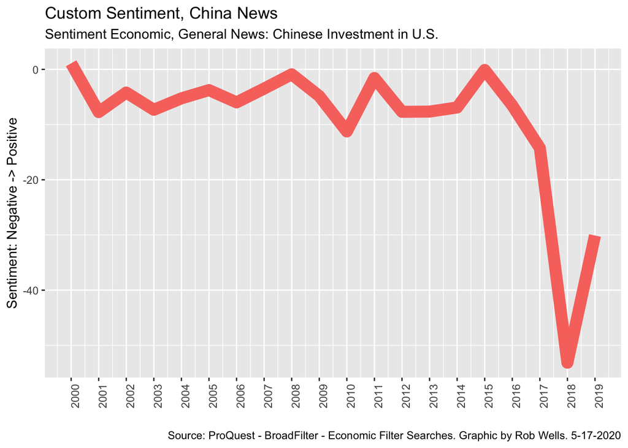

```r
BF_EFcust %>%
ggplot(aes(x= year, y= index, color = "red", size = 3)) +
#ggplot(aes(x= year, y= index, color = index > -4.469829, size = 3)) +
  geom_line() +
  scale_x_continuous(breaks=c(2000:2019)) +
  theme(legend.position = "none") +
   theme(axis.text.x = element_text(angle = 90, hjust = 1)) +
   labs(title = "Custom Sentiment, China News",
       subtitle = "Sentiment Economic, General News: Chinese Investment in U.S.",
       caption = "Source: ProQuest - BroadFilter - Economic Filter Searches. Graphic by Rob Wells. 5-17-2020",
       x=" ",
       y="Sentiment: Negative -> Positive")
```

```r
#ggsave("./Sentiment Analysis/BF_EFcust.png",device = "png",width=10,height=8, dpi=800)
```

### And for comparison sake, here is a repeat of the sentiment using the Bing index

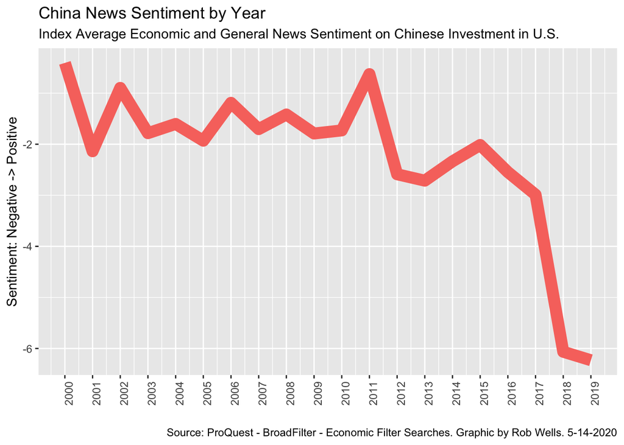